# Optimizing EdTech Leads Project

### Author: Spencer Rogovin

## Context

The EdTech industry has been surging in the past decade immensely, and according to a forecast, the Online Education market would be worth $286.62bn by 2023 with a compound annual growth rate (CAGR) of 10.26% from 2018 to 2023. The modern era of online education has enforced a lot in its growth and expansion beyond any limit. Due to having many dominant features like ease of information sharing, personalized learning experience, transparency of assessment, etc, it is now preferable to traditional education.

In the present scenario due to the Covid-19, the online education sector has witnessed rapid growth and is attracting a lot of new customers. Due to this rapid growth, many new companies have emerged in this industry. With the availability and ease of use of digital marketing resources, companies can reach out to a wider audience with their offerings. The customers who show interest in these offerings are termed as leads. There are various sources of obtaining leads for Edtech companies, like

- The customer interacts with the marketing front on social media or other online platforms.
- The customer browses the website/app and downloads the brochure
- The customer connects through emails for more information.

The company then nurtures these leads and tries to convert them to paid customers. For this, the representative from the organization connects with the lead on call or through email to share further details.

### Objective

ExtraaLearn is an initial stage startup that offers programs on cutting-edge technologies to students and professionals to help them upskill/reskill. With a large number of leads being generated on a regular basis, one of the issues faced by ExtraaLearn is to identify which of the leads are more likely to convert so that they can allocate resources accordingly. This project utilizes a variety of Machine Learning models and exploratory data analysis techniques to help identify which leads are more likely to convert to paid customers, and the factors driving the lead conversion process.

**Data Dictionary**

- ID: ID of the lead
- age: Age of the lead
- current_occupation: Current occupation of the lead. Values include 'Professional','Unemployed',and 'Student'
- first_interaction: How did the lead first interacted with ExtraaLearn. Values include 'Website', 'Mobile App'
- profile_completed: What percentage of profile has been filled by the lead on the website/mobile app. Values include Low - (0-50%), Medium - (50-75%), High (75-100%)
- website_visits: How many times has a lead visited the website
- time_spent_on_website: Total time spent on the website
- page_views_per_visit: Average number of pages on the website viewed during the visits.
- last_activity: Last interaction between the lead and ExtraaLearn.
  - Email Activity: Seeking for details about program through email, Representative shared information with lead like brochure of program , etc
  - Phone Activity: Had a Phone Conversation with representative, Had conversation over SMS with representative, etc
  - Website Activity: Interacted on live chat with representative, Updated profile on website, etc
- print_media_type1: Flag indicating whether the lead had seen the ad of ExtraaLearn in the Newspaper.
- print_media_type2: Flag indicating whether the lead had seen the ad of ExtraaLearn in the Magazine.
- digital_media: Flag indicating whether the lead had seen the ad of ExtraaLearn on the digital platforms.
- educational_channels: Flag indicating whether the lead had heard about ExtraaLearn in the education channels like online forums, discussion threads, educational websites, etc.
- referral: Flag indicating whether the lead had heard about ExtraaLearn through reference.
- status: Flag indicating whether the lead was converted to a paid customer or not.

## Importing necessary libraries and data

```python
import warnings

warnings.filterwarnings("ignore")
from statsmodels.tools.sm_exceptions import ConvergenceWarning

warnings.simplefilter("ignore", ConvergenceWarning)

import pandas as pd
import numpy as np

# Split data library
from sklearn.model_selection import train_test_split

# data visualization libraries
import matplotlib.pyplot as plt
import seaborn as sns

# limit for displayed columns removed
pd.set_option("display.max_columns", None)
# limit for displayed rows set
pd.set_option("display.max_rows", 200)
# precision of floating numbers set to 5 decimal points
pd.set_option("display.float_format", lambda x: "%.5f" % x)

# To build model for prediction
import statsmodels.stats.api as sms
from statsmodels.stats.outliers_influence import variance_inflation_factor
import statsmodels.api as sm
from statsmodels.tools.tools import add_constant
from sklearn.linear_model import LogisticRegression
from sklearn.tree import DecisionTreeClassifier
from sklearn import tree
from sklearn.ensemble import RandomForestClassifier

# Tuning tools
from sklearn.model_selection import GridSearchCV


# To get metrics
import sklearn.metrics as metrics
from sklearn.metrics import (
    f1_score,
    accuracy_score,
    recall_score,
    precision_score,
    confusion_matrix,
    classification_report,
    roc_auc_score,
    precision_recall_curve,
    roc_curve,
    make_scorer,
)
```

```python
## Loading dataset
learn = pd.read_csv("ExtraaLearn.csv")
```

```python
# copy of data to another variable to avoid changes to original data
data = learn.copy()
```

## Data Overview

- Observations
- Sanity checks

```python
## View first & last 5 rows of dataset
print(data.head())
print(data.tail())
```

```
       ID  age current_occupation first_interaction profile_completed  \
0  EXT001   57         Unemployed           Website              High
1  EXT002   56       Professional        Mobile App            Medium
2  EXT003   52       Professional           Website            Medium
3  EXT004   53         Unemployed           Website              High
4  EXT005   23            Student           Website              High

   website_visits  time_spent_on_website  page_views_per_visit  \
0               7                   1639               1.86100
1               2                     83               0.32000
2               3                    330               0.07400
3               4                    464               2.05700
4               4                    600              16.91400

      last_activity print_media_type1 print_media_type2 digital_media  \
```

[output cut: 39 more lines]

```python
print(data.shape) ## shape of dataset
print(data.dtypes) ## data types for columns
print(data.duplicated().sum()) ## duplicate value check
```

```
(4612, 15)
ID                        object
age                        int64
current_occupation        object
first_interaction         object
profile_completed         object
website_visits             int64
time_spent_on_website      int64
page_views_per_visit     float64
last_activity             object
print_media_type1         object
print_media_type2         object
digital_media             object
educational_channels      object
referral                  object
status                     int64
dtype: object
0
```

## Data Preprocessing & Exploratory Data Analysis (EDA)

```python
# import Data Preprocessing libraries
from sklearn.preprocessing import OneHotEncoder, StandardScaler
from sklearn.compose import ColumnTransformer
from sklearn.pipeline import Pipeline
from sklearn.model_selection import train_test_split
```

```python
# renove irrelevant columns or columns with too many missing values
edtech_leads = data.drop(columns=['ID', 'last_activity'])

# Separate features and target variable
X = data.drop(columns=['status'])
y = data['status']

# Encode categorical variables
categorical_features = ['current_occupation', 'first_interaction', 'profile_completed']
numerical_features = ['age', 'website_visits', 'time_spent_on_website', 'page_views_per_visit']
binary_features = ['print_media_type1', 'print_media_type2', 'digital_media', 'educational_channels', 'referral']
```

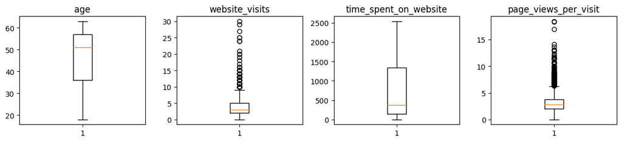

```python
# OUTLIER CHECK USIN
numeric_columns = edtech_leads.select_dtypes(include=np.number).columns.tolist()
# drop release_year because it is a time-based variable --> n/a to outlier check
numeric_columns.remove("status")


plt.figure(figsize=(12, 10))

for i, variable in enumerate(numeric_columns):
    plt.subplot(4, 4, i + 1)
    plt.boxplot(data[variable], whis=1.5)
    plt.tight_layout()
    plt.title(variable)

plt.show()
```

```python
edtech_leads.describe() ##  statistical summary of the data
```

|  | age | website_visits | time_spent_on_website | page_views_per_visit | status |
| --- | --- | --- | --- | --- | --- |
| count | 4612.00000 | 4612.00000 | 4612.00000 | 4612.00000 | 4612.00000 |
| mean | 46.20121 | 3.56678 | 724.01127 | 3.02613 | 0.29857 |
| std | 13.16145 | 2.82913 | 743.82868 | 1.96812 | 0.45768 |
| min | 18.00000 | 0.00000 | 0.00000 | 0.00000 | 0.00000 |
| 25% | 36.00000 | 2.00000 | 148.75000 | 2.07775 | 0.00000 |
| 50% | 51.00000 | 3.00000 | 376.00000 | 2.79200 | 0.00000 |
| 75% | 57.00000 | 5.00000 | 1336.75000 | 3.75625 | 1.00000 |
| max | 63.00000 | 30.00000 | 2537.00000 | 18.43400 | 1.00000 |

```python
# unique values in the "ID" column
print("Number of unique values in 'ID' column:", data["ID"].nunique())
```

```
Number of unique values in 'ID' column: 4612
```

```python
## SETTING UP UNIVARIATE ANALYSIS OF NUMERICAL FEATURES
# function to plot a boxplot and a histogram along the same scale.


def histogram_boxplot(edtech_leads, feature, figsize=(11, 6), kde=False, bins=None):
    """
    Boxplot and histogram combined

    data: dataframe
    feature: dataframe column
    figsize: size of figure (default (11,6))
    kde: whether to the show density curve (default False)
    bins: number of bins for histogram (default None)
    """
    f2, (ax_box2, ax_hist2) = plt.subplots(
        nrows=2,  # Number of rows of the subplot grid= 2
        sharex=True,  # x-axis shared amongst all subplots
        gridspec_kw={"height_ratios": (0.20, 0.68)},
        figsize=figsize,
    )  # creating the 2 subplots
    sns.boxplot(
        data=data, x=feature, ax=ax_box2, showmeans=True, color="violet"
    )  # boxplot will be created and a star will indicate the mean value of the column
    sns.histplot(
        data=data, x=feature, kde=kde, ax=ax_hist2, bins=bins, palette="summer"
    ) if bins else sns.histplot(
        data=data, x=feature, kde=kde, ax=ax_hist2
    )  # For histogram
    ax_hist2.axvline(
        data[feature].mean(), color="red", linestyle="--"
    )  # Add mean to the histogram
    ax_hist2.axvline(
        data[feature].median(), color="blue", linestyle="-"
    )  # Add median to the histogram
```

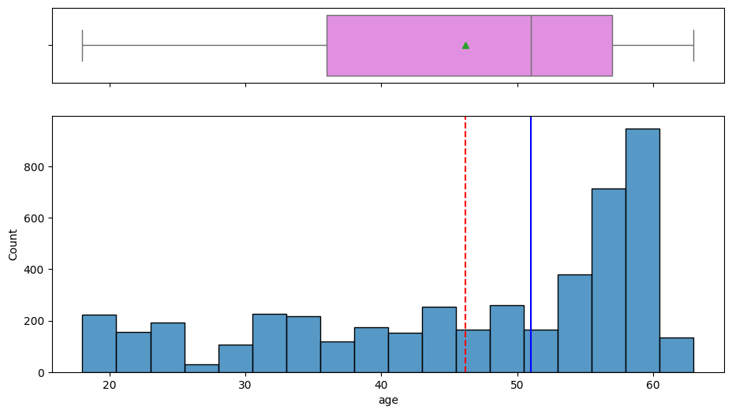

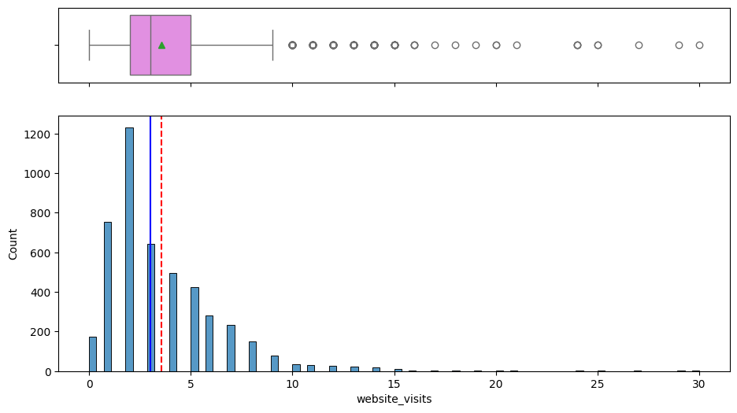

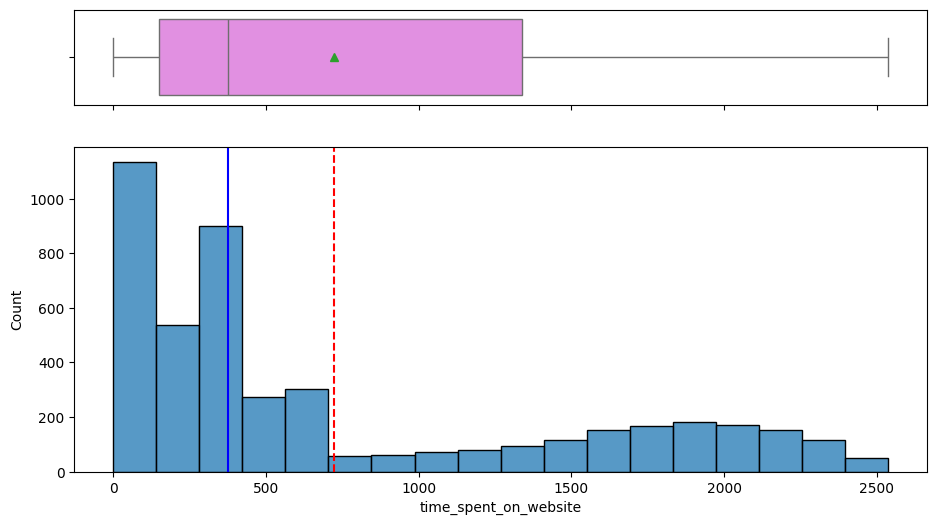

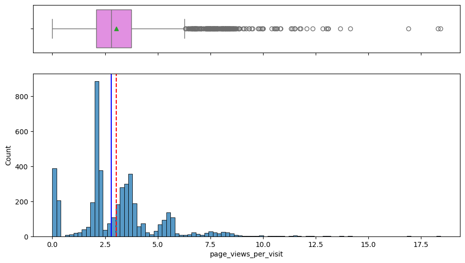

```python
## UNIVARIATE ANALYSIS OF NUMERICAL FEATURES
histogram_boxplot(edtech_leads, "age")
histogram_boxplot(edtech_leads, "website_visits")
histogram_boxplot(edtech_leads, "time_spent_on_website")
histogram_boxplot(edtech_leads, "page_views_per_visit")
```

```python
## SETTING UP UNIVARIATE ANALYSIS OF CATEGORICAL & BINARY FEATURES

def labeled_barplot(edtech_leads, feature, perc=False, n=None):
    """
    Barplot with percentage at the top

    data: dataframe
    feature: dataframe column
    perc: whether to display percentages instead of count (default is False)
    n: displays the top n category levels (default is None, i.e., display all levels)
    """

    total = len(edtech_leads[feature])  # column length
    count = edtech_leads[feature].nunique()
    if n is None:
        plt.figure(figsize=(count + 1, 5))
    else:
        plt.figure(figsize=(n + 1, 5))

    plt.xticks(rotation=90, fontsize=13)
    ax = sns.countplot(
        data=edtech_leads,
        x=feature,
        palette="Paired",
        order=edtech_leads[feature].value_counts().index[:n].sort_values(),
    )

    for p in ax.patches:
        if perc == True:
            label = "{:.1f}%".format(
                100 * p.get_height() / total
            )  # percentage of each class of the category
        else:
            label = p.get_height()  # count of each level of the category

        x = p.get_x() + p.get_width() / 2  # width of the plot
        y = p.get_height()  # height of the plot

        ax.annotate(
            label,
            (x, y),
            ha="center",
            va="center",
            size=12,
            xytext=(0, 5),
            textcoords="offset points",
        )  # annotates the percentage

    plt.show()  # shows plot
```

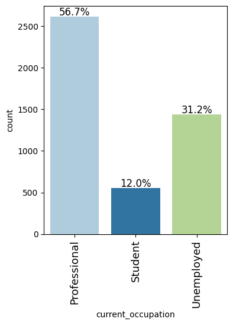

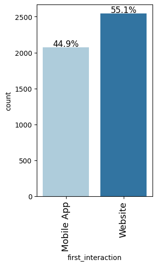

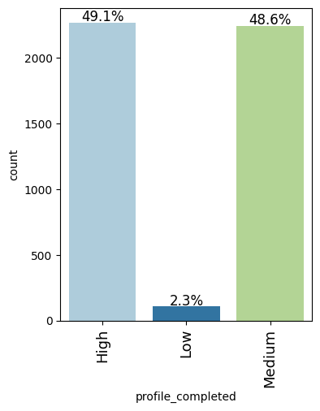

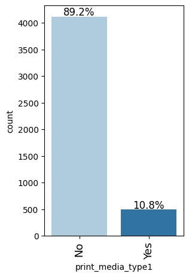

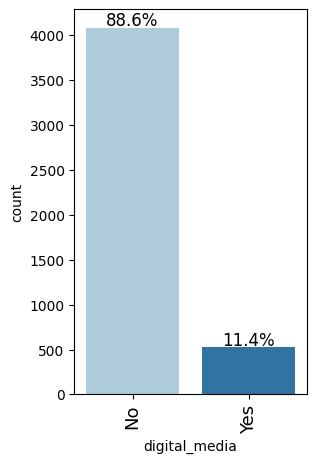

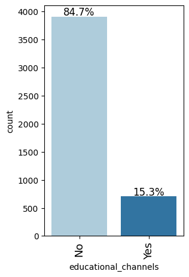

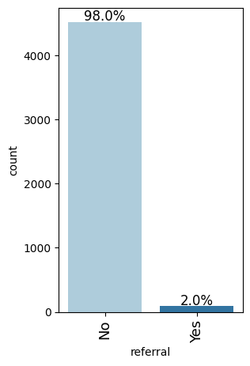

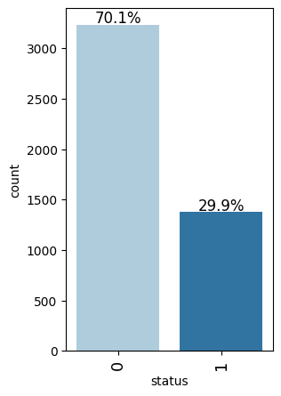

```python
## UNIVARIATE ANALYSIS OF CATEGORICAL & BINARY FEATURES
labeled_barplot(edtech_leads, "current_occupation", perc=True)
labeled_barplot(edtech_leads, "first_interaction", perc=True)
labeled_barplot(edtech_leads, "profile_completed", perc=True)
labeled_barplot(edtech_leads, "print_media_type1", perc=True)
labeled_barplot(edtech_leads, "digital_media", perc=True)
labeled_barplot(edtech_leads, "educational_channels", perc=True)
labeled_barplot(edtech_leads, "referral", perc=True)
labeled_barplot(edtech_leads, "status", perc=True)
```

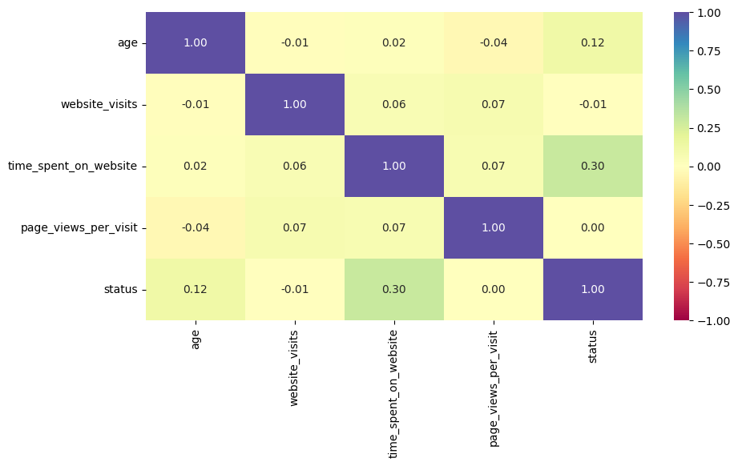

```python
## BIVARIATE ANALYSIS
cols_list = edtech_leads.select_dtypes(include=np.number).columns.tolist()

plt.figure(figsize=(10, 5))
sns.heatmap(
    edtech_leads[cols_list].corr(), annot=True, vmin=-1, vmax=1, fmt=".2f", cmap="Spectral"
)
plt.show()
```

```python
## STACKED BARPLOT FOR BIVARIATE ANALYSIS
def stacked_barplot(edtech_leads, predictor, target):
    """
    Print the category counts and plot a stacked bar chart

    data: dataframe
    predictor: independent variable
    target: target variable
    """
    count = edtech_leads[predictor].nunique()
    sorter = edtech_leads[target].value_counts().index[-1]
    tab1 = pd.crosstab(edtech_leads[predictor], edtech_leads[target], margins=True).sort_values(
        by=sorter, ascending=False
    )
    print(tab1)
    print("-" * 120)
    tab = pd.crosstab(edtech_leads[predictor], edtech_leads[target], normalize="index").sort_values(
        by=sorter, ascending=False
    )
    tab.plot(kind="bar", stacked=True, figsize=(count + 5, 5))
    plt.legend(
        loc="lower left", frameon=False,
    )
    plt.legend(loc="upper left", bbox_to_anchor=(1, 1))
    plt.show()
```

```
status                 0     1   All
current_occupation
All                 3235  1377  4612
Professional        1687   929  2616
Unemployed          1058   383  1441
Student              490    65   555
------------------------------------------------------------------------------------------------------------------------
```

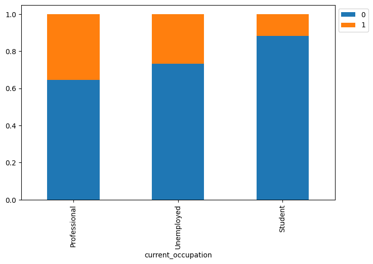

```
age                 18  19  20  21  22  23  24  25  26  27  28  29  30  31  \
current_occupation
Professional         0   0   0   0   0   0   0  16  15  14  27  36  44  38
All                 66  81  75  86  71  85  90  17  15  14  27  36  44  38
Student             66  81  75  86  71  85  90   1   0   0   0   0   0   0
Unemployed           0   0   0   0   0   0   0   0   0   0   0   0   0   0

age                  32  33  34  35  36  37  38  39  40  41  42  43  44  45  \
current_occupation
Professional         53  46  52  44  30  40  41  32  40  51  55  56  49  49
All                 188  76  74  66  58  60  58  52  63  70  83  89  81  84
Student               0   0   0   0   0   0   0   0   0   0   0   0   0   0
Unemployed          135  30  22  22  28  20  17  20  23  19  28  33  32  35

age                 46  47  48  49  50  51  52  53  54   55   56   57   58  \
current_occupation
Professional        53  52  56  61  53  60  53  59  65  134  252  282  256
All                 85  80  88  87  85  88  77  91  88  200  330  385  382
Student              0   0   0   0   0   0   0   0   0    0    0    0    0
Unemployed          32  28  32  26  32  28  24  32  23   66   78  103  126

age                  59   60  61  62  63   All
current_occupation
Professional        217  135   0   0   0  2616
All                 328  238  38  48  47  4612
Student               0    0   0   0   0   555
Unemployed          111  103  38  48  47  1441
------------------------------------------------------------------------------------------------------------------------
```

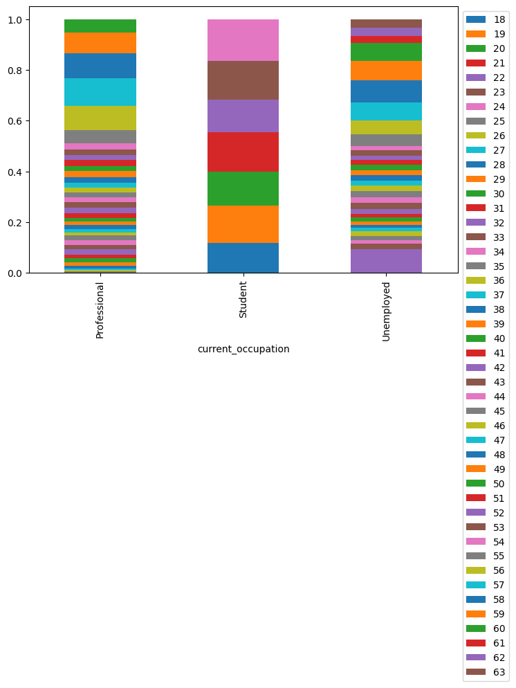

```
status     0     1   All
age
All     3235  1377  4612
57       249   136   385
59       207   121   328
58       262   120   382
56       210   120   330
60       162    76   238
55       128    72   200
32       133    55   188
53        51    40    91
50        48    37    85
45        51    33    84
34        43    31    74
46        56    29    85
```

[output cut: 35 more lines]

[figure not shown]

```
status                0     1   All
print_media_type1
All                3235  1377  4612
No                 2897  1218  4115
Yes                 338   159   497
------------------------------------------------------------------------------------------------------------------------
```

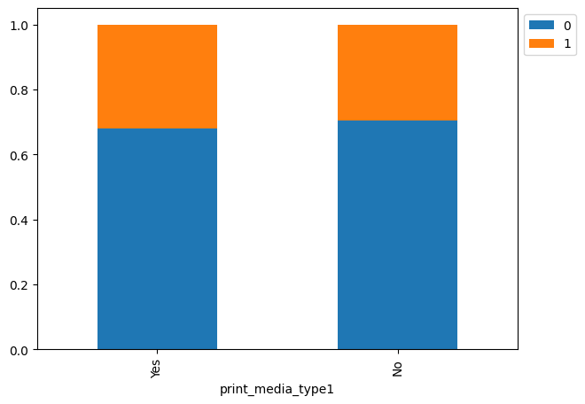

```
status                0     1   All
print_media_type2
All                3235  1377  4612
No                 3077  1302  4379
Yes                 158    75   233
------------------------------------------------------------------------------------------------------------------------
```

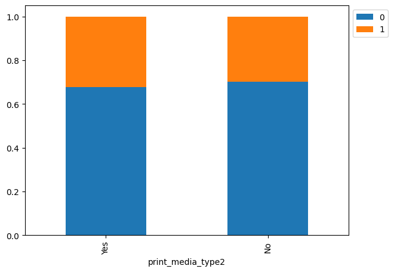

```
status            0     1   All
digital_media
All            3235  1377  4612
No             2876  1209  4085
Yes             359   168   527
------------------------------------------------------------------------------------------------------------------------
```

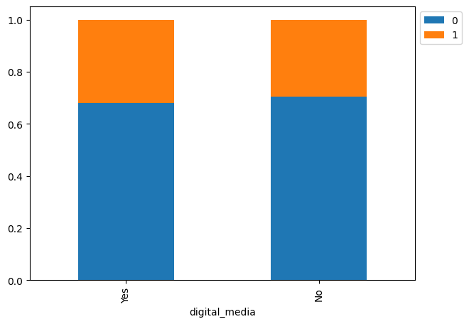

```
status       0     1   All
referral
All       3235  1377  4612
No        3205  1314  4519
Yes         30    63    93
------------------------------------------------------------------------------------------------------------------------
```

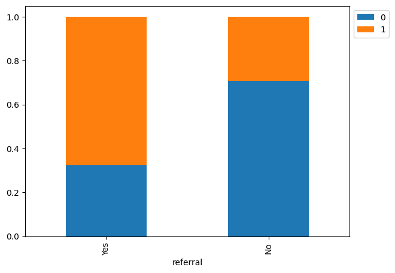

```python
## BIVARIATE ANALYSIS THAT DESCRIBES LEAD DEMOGRAPHICS
stacked_barplot(edtech_leads, "current_occupation", "status") ## OCCUPATION V STATUS
stacked_barplot(edtech_leads, "current_occupation", "age") ## OCCUPATION V AGE
stacked_barplot(edtech_leads, "age", "status") ## AGE V STATUS
## BIVARIATE ANALYSIS THAT SHOWS HOW LEADS RECEIVED ADVERTISEMENTS AND OR REFERALLS --> AND THE RESULTS
stacked_barplot(edtech_leads, "print_media_type1", "status")
stacked_barplot(edtech_leads, "print_media_type2", "status")
stacked_barplot(edtech_leads, "digital_media", "status")
stacked_barplot(edtech_leads, "referral", "status")
```

## Building a Decision Tree model

```python
X = pd.get_dummies(X, drop_first=True)
Y = edtech_leads["status"] ## Coding dependent variable
# Split data 70:30 ]for train to test data
X_train, X_test, y_train, y_test = train_test_split(
    X, Y, test_size=0.30, random_state=1
)
print("Shape of Training set : ", X_train.shape)
print("Shape of test set : ", X_test.shape)
print("Percentage of classes in training set:")
print(y_train.value_counts(normalize=True))
print("Percentage of classes in test set:")
print(y_test.value_counts(normalize=True))
```

```
Shape of Training set :  (3228, 4627)
Shape of test set :  (1384, 4627)
Percentage of classes in training set:
status
0   0.70415
1   0.29585
Name: proportion, dtype: float64
Percentage of classes in test set:
status
0   0.69509
1   0.30491
Name: proportion, dtype: float64
```

```python
## CLASSIFICATION REPORT/BREAKDOWN

def metrics_score(actual, predicted):
    print(classification_report(actual, predicted))

    cm = confusion_matrix(actual, predicted)

    plt.figure(figsize = (8, 5))

    sns.heatmap(cm, annot = True,  fmt = '.2f', xticklabels = ['Not Converted', 'Converted'], yticklabels = ['Not Converted', 'Converted'])

    plt.ylabel('Actual')

    plt.xlabel('Predicted')

    plt.show()
```

```
Performance on Training Data:
              precision    recall  f1-score   support

           0       1.00      1.00      1.00      2273
           1       1.00      1.00      1.00       955

    accuracy                           1.00      3228
   macro avg       1.00      1.00      1.00      3228
weighted avg       1.00      1.00      1.00      3228
```

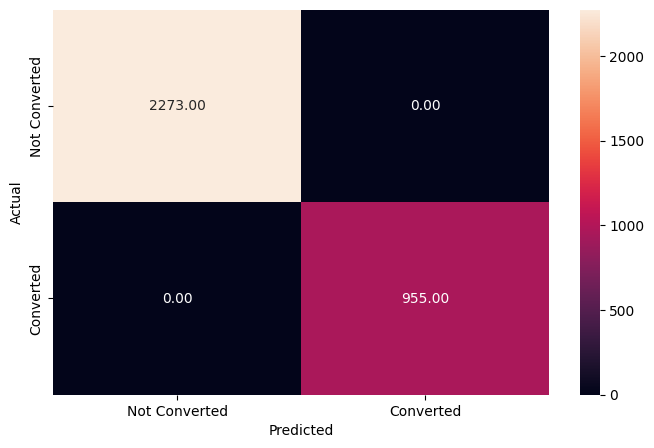

```
Performance on Testing Data:
              precision    recall  f1-score   support

           0       0.88      0.90      0.89       962
           1       0.75      0.71      0.73       422

    accuracy                           0.84      1384
   macro avg       0.81      0.80      0.81      1384
weighted avg       0.84      0.84      0.84      1384
```

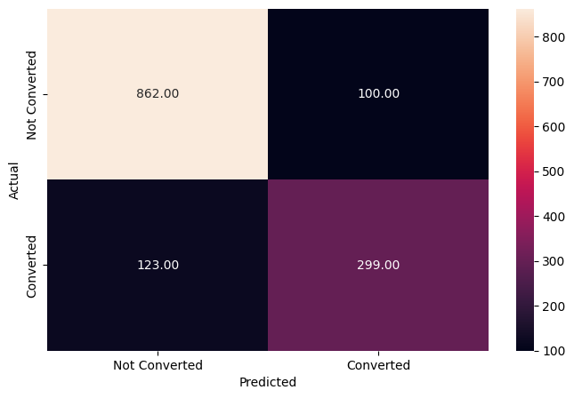

```python
## BUILDING DECISION TREE MODEL
d_tree = DecisionTreeClassifier()  # Create DecisionTreeClassifier
d_tree.fit(X_train, y_train)  # Fit classifier on training data
# performance check on training data
y_pred_train1 = d_tree.predict(X_train)
print("Performance on Training Data:")
metrics_score(y_train, y_pred_train1)
# performance check on testing data
y_pred_test1 = d_tree.predict(X_test)
print("Performance on Testing Data:")
metrics_score(y_test, y_pred_test1)
```

** OBSERVATIONS: The model performed extremely well on the training data, achieving perfect precision, recall, and accuracy. It is obvious that the model is overfitting the training data. This is also shown through the discrepancy between the performance on the training data & testing data.

```python
# Choosing classifier type
d_tree_tuned = DecisionTreeClassifier(random_state = 7, class_weight = {0: 0.3, 1: 0.7})
# parameter grid
parameters = {'max_depth': np.arange(2, 10),
              'criterion': ['gini', 'entropy'],
              'min_samples_leaf': [5, 10, 20, 25]
             }
#  scoring used to compare parameter combinations - recall score for class 1
scorer = metrics.make_scorer(recall_score, pos_label = 1)
# grid search
grid_obj = GridSearchCV(d_tree_tuned, parameters, scoring = scorer, cv = 5)
grid_obj = grid_obj.fit(X_train, y_train)
# best combination of parameters
d_tree_tuned = grid_obj.best_estimator_
# Fit the best algorithm to the data
d_tree_tuned.fit(X_train, y_train)
```

```
DecisionTreeClassifier(class_weight={0: 0.3, 1: 0.7}, criterion='entropy',
                       max_depth=3, min_samples_leaf=5, random_state=7)
```

```
              precision    recall  f1-score   support

           0       0.93      0.77      0.84       962
           1       0.62      0.86      0.72       422

    accuracy                           0.80      1384
   macro avg       0.77      0.82      0.78      1384
weighted avg       0.83      0.80      0.80      1384
```

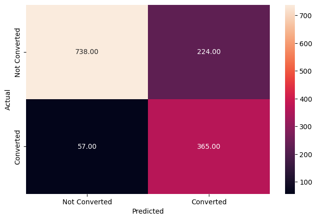

```python
## Performance Check 2 on data
y_pred_train2 = d_tree_tuned.predict(X_train)
y_pred_test2 = d_tree_tuned.predict(X_test)
metrics_score(y_test, y_pred_test2)
```

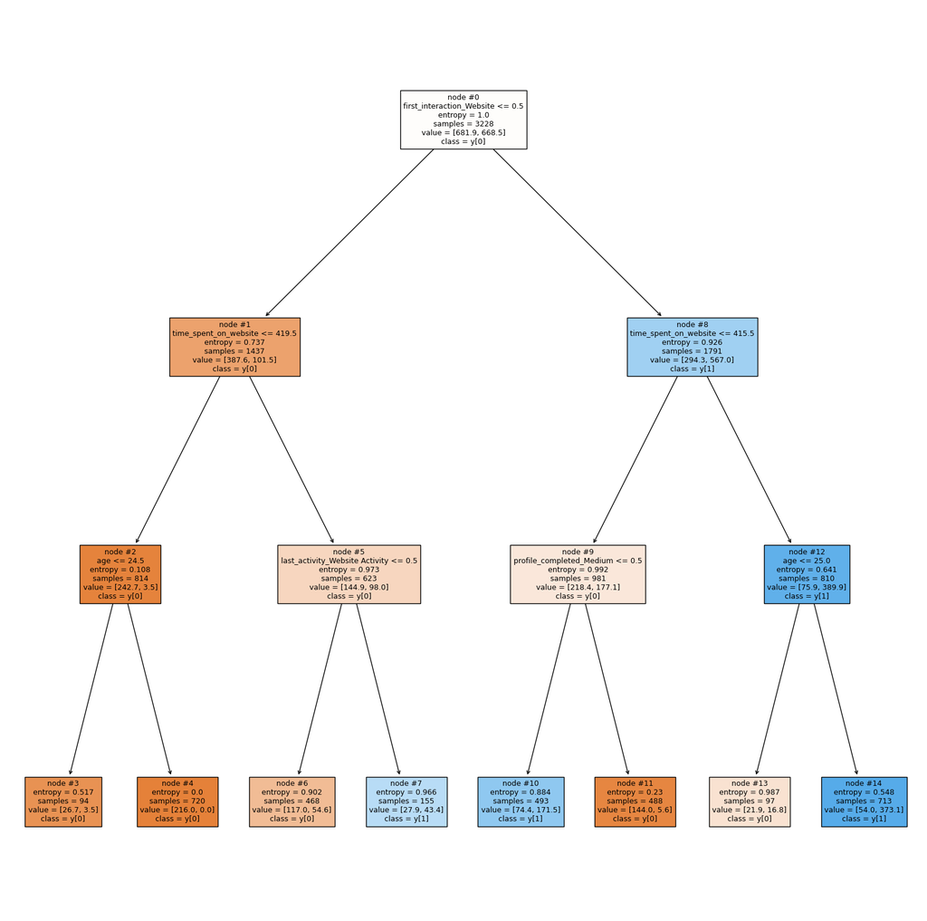

```python
## VISUALISATION OF DECISION TREE
features = list(X.columns)

plt.figure(figsize = (20, 20))

tree.plot_tree(d_tree_tuned, feature_names = features, filled = True, fontsize = 9, node_ids = True, class_names = True)

plt.show()
```

OBSERVATIONS: Most of the classes are split evenly. The original 3228 samples are split into two nodes, one containing apporximately 55% of the samples in node #8 and 45% of the samples in node #1. The criteria for the nodes/classes that the decision treep produced were based on entropy. The decision tree makes a lot of these decisions with a high calculated entropy. 3 out of the final 8 nodes had an entropy greater than 0.9. While node #11 had an entropy of 0.23, node #4 had an entropy of 0.0, indicating full purtiy amongst that node.

## Do we need to prune the tree?

Yes the tree should be pruned since many of the classes were made with high uncertainty.

## Building a Random Forest model

```python
# Fitting the random forest tree classifier on the training data
rf_estimator = RandomForestClassifier(n_estimators=100, max_depth=5, min_samples_split=2)
rf_estimator.fit(X_train, y_train)
```

```
RandomForestClassifier(max_depth=5)
```

```
Performance on Training Data:
              precision    recall  f1-score   support

           0       0.70      1.00      0.83      2273
           1       0.00      0.00      0.00       955

    accuracy                           0.70      3228
   macro avg       0.35      0.50      0.41      3228
weighted avg       0.50      0.70      0.58      3228
```

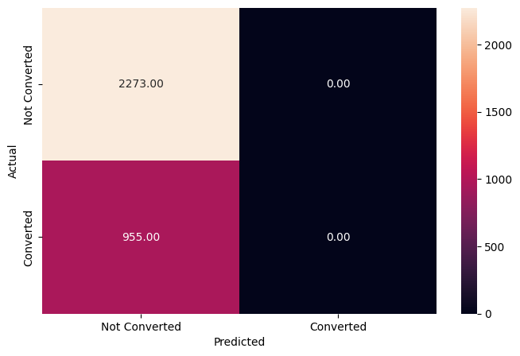

```
Performance on Testing Data:
              precision    recall  f1-score   support

           0       0.70      1.00      0.82       962
           1       0.00      0.00      0.00       422

    accuracy                           0.70      1384
   macro avg       0.35      0.50      0.41      1384
weighted avg       0.48      0.70      0.57      1384
```

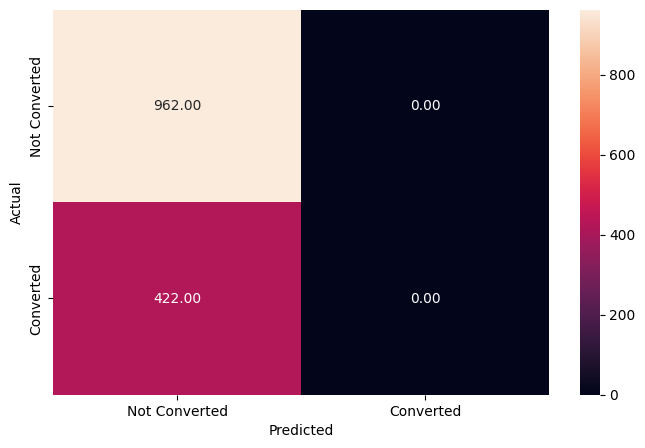

```python
# predictions on the training data
y_pred_train3 = rf_estimator.predict(X_train)
# Checking performance on the testing data
y_pred_test3 = rf_estimator.predict(X_test)

print("Performance on Training Data:")
metrics_score(y_train, y_pred_train3)

print("Performance on Testing Data:")
metrics_score(y_test, y_pred_test3)
```

** OBSERVATIONS: Zeros in class one suggest extremely poor performance, and the need for more fine tuning and even pruning, since the model is highly uniterpretable.

## Actionable Insights and Recommendations

In terms of values that stood out & held significance;

- Referrals were the lowest source of leads — only 2%
- Time spent on website had the highest correlation to lead status out of all numerical categories
- The distribution of the age of leads is strongly skewed to the left

```python
!pip install nbconvert
!jupyter nbconvert --to html Optimizing_EdTech_Lead_Conversion_Rates_SpencerRogovin_.ipynb
```

```
[NbConvertApp] Converting notebook Optimizing_EdTech_Lead_Conversion_Rates_SpencerRogovin_.ipynb to html
[NbConvertApp] Writing 1611051 bytes to Optimizing_EdTech_Lead_Conversion_Rates_SpencerRogovin_.html
```